# team.Rmd

John Nownes

4/14/2020

## Part 1

```r
acc <- read.csv("https://raw.githubusercontent.com/xdaiISU/ds202materials/master/hwlabs/fars2017/accident.csv", stringsAsFactors = FALSE)

person <- read.csv("https://raw.githubusercontent.com/xdaiISU/ds202materials/master/hwlabs/fars2017/person.csv", stringsAsFactors = FALSE)


table(acc$DAY_WEEK)
```

```
##
##    1    2    3    4    5    6    7
## 5360 4374 4347 4314 4621 5358 5873
```

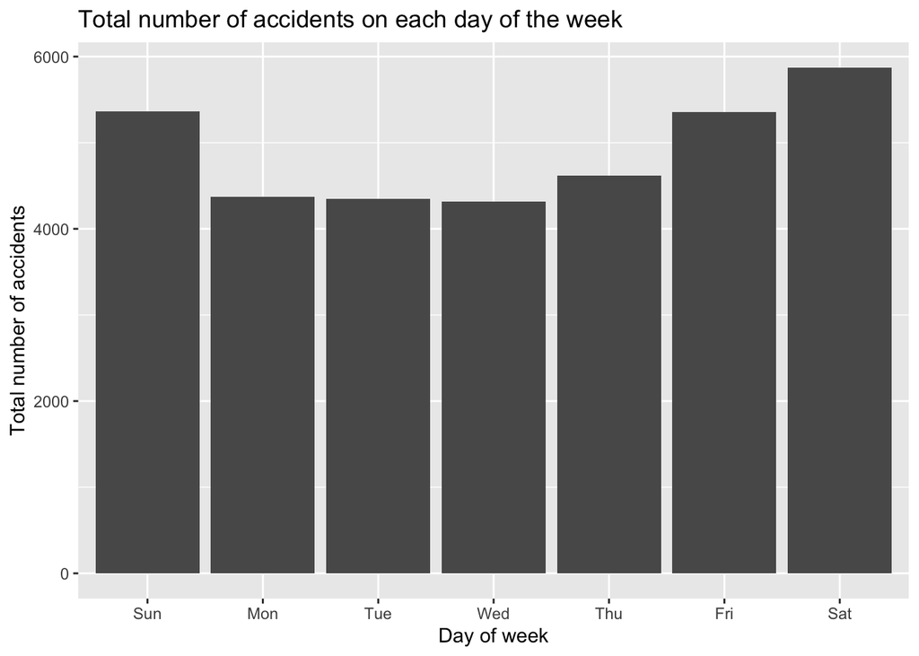

```r
ggplot(acc, mapping = aes(x=wday(DAY_WEEK, label = TRUE))) + geom_bar() + xlab("Day of week") + ylab("Total number of accidents") + ggtitle("Total number of accidents on each day of the week")
```

From the table and graph above, it is clear that on Friday, Saturday, and Sunday there are a greater number of accidents than on Monday, Tuesday, Wednesday, and Thursday.

```r
table(acc$HOUR)
```

```
##
##    0    1    2    3    4    5    6    7    8    9   10   11   12   13   14   15
## 1321 1177 1241  957  813 1065 1282 1162  945  929 1064 1198 1403 1480 1613 1760
##   16   17   18   19   20   21   22   23   99
## 1770 1916 2000 1880 1930 1880 1683 1516  262
```

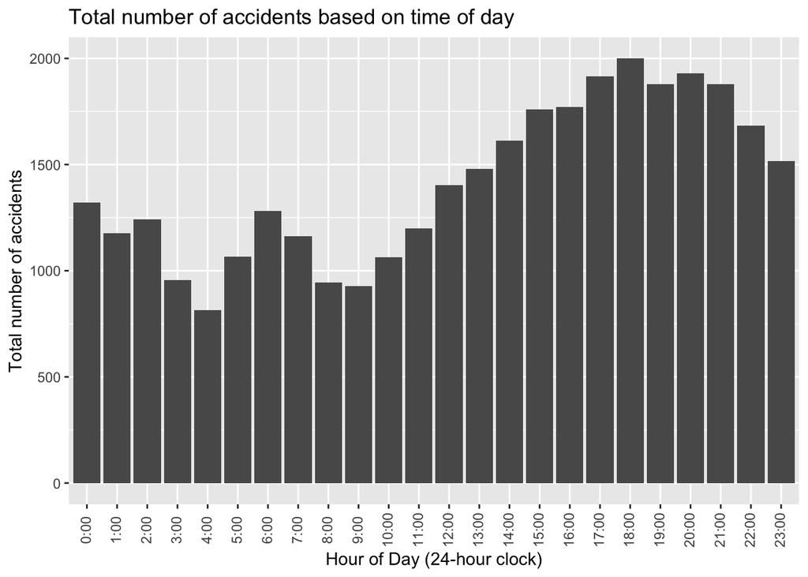

```r
acc %>%
  filter(HOUR < 24) %>%
  ggplot(mapping = aes(x=factor(as.factor(paste(HOUR,":00",sep="")), levels= c("0:00","1:00","2:00","3:00","4:00","5:00","6:00","7:00","8:00","9:00","10:00","11:00","12:00","13:00","14:00","15:00","16:00","17:00","18:00","19:00","20:00","21:00","22:00","23:00")))) + geom_bar() + xlab("Hour of Day (24-hour clock)") + ylab("Total number of accidents") + ggtitle("Total number of accidents based on time of day") + theme(axis.text.x = element_text(angle = 90, vjust = .4))
```

Based on the above graph, the highest number of accidents occur between 15:00 and 22:00, or from 3-10pm. Something to note about the above graph is that “:00” was concatenated to the end of each hour of the day. This makes the graph more easily interpretable, but to order the hours in the correct sequence, conversion to factors is necessary. The result is a graph that anyone with knowledge of the 24-hour clock can understand.

```r
nrow(acc %>%
  filter(DRUNK_DR > 0))
```

```
## [1] 8769
```

There were 8769 accidents with at least one drunk driver. This is out of the total 34,247 total accidents, so we can say that about 25% of accidents occur with at least one drunk driver. However, from the FARS Analytical User’s Manual, the DRUNK_DR statistic is “unreliable for 1977, 1981, and 1999-2007, as it was incorrectly derived for those years.”

## Part 2

```r
person = person %>%
  filter(PER_TYP == 1)
```

```r
combined <- acc %>%
  full_join(person, by = c('STATE', 'ST_CASE', 'COUNTY', 'DAY', 'MONTH', 'HOUR', 'MINUTE'))
```

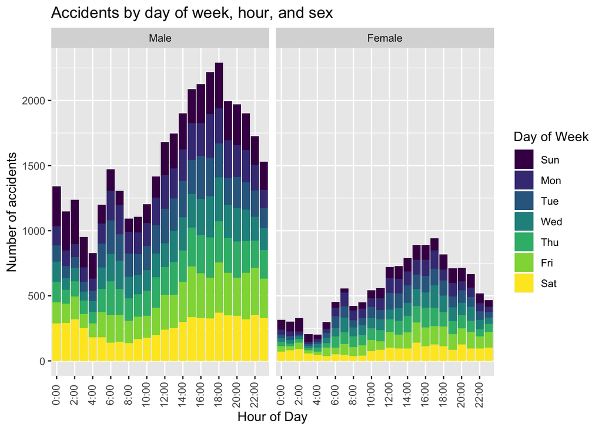

```r
combined$SEX <- factor(combined$SEX, labels = c("Male","Female", "Not Reported", "Unknown"))

combined %>%
  filter(SEX == 'Male' | SEX == 'Female') %>%
  filter(HOUR <= 24) %>%
  ggplot(aes(x=factor(as.factor(paste(HOUR,":00",sep="")), levels= c("0:00","1:00","2:00","3:00","4:00","5:00","6:00","7:00","8:00","9:00","10:00","11:00","12:00","13:00","14:00","15:00","16:00","17:00","18:00","19:00","20:00","21:00","22:00","23:00")), fill=wday(DAY_WEEK, label = TRUE))) + geom_bar() + facet_wrap(~SEX) + labs(x= "Hour of Day", y= "Number of accidents",fill = "Day of Week", title="Accidents by day of week, hour, and sex") + theme(axis.text.x = element_text(angle = 90, vjust = .4)) + scale_x_discrete(breaks=c("0:00","2:00","4:00","6:00","8:00","10:00","12:00","14:00","16:00","18:00","20:00","22:00"))
```

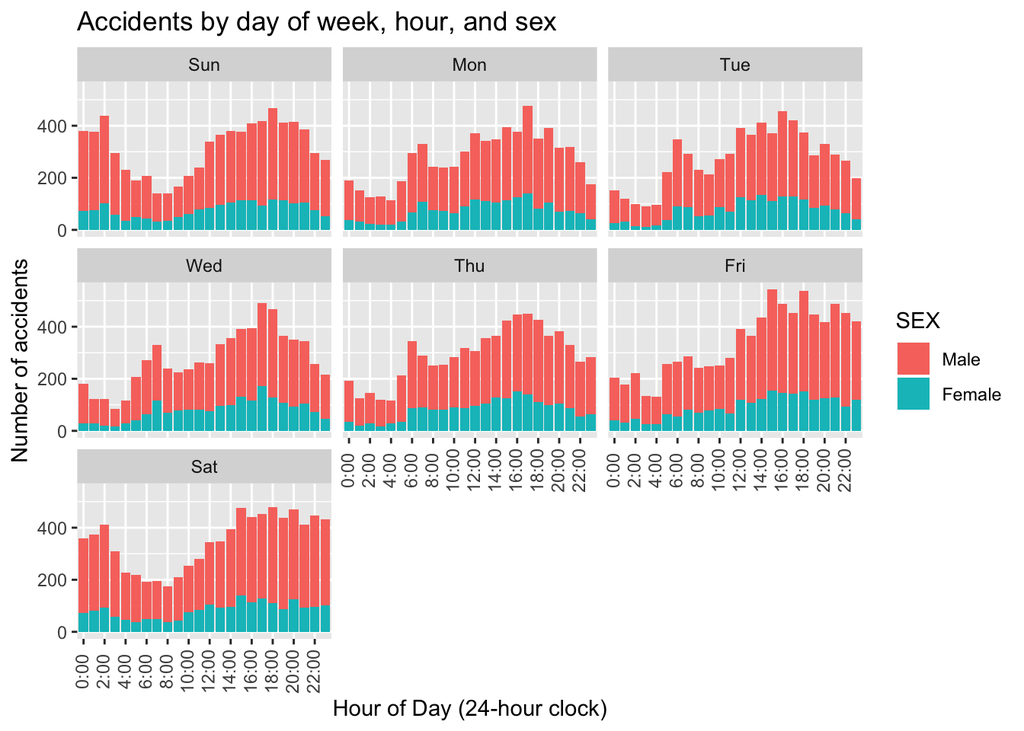

```r
combined %>%
  filter(SEX == "Male" | SEX == "Female") %>%
  filter(HOUR <= 24) %>%
  ggplot(aes(x=factor(as.factor(paste(HOUR,":00",sep="")), levels= c("0:00","1:00","2:00","3:00","4:00","5:00","6:00","7:00","8:00","9:00","10:00","11:00","12:00","13:00","14:00","15:00","16:00","17:00","18:00","19:00","20:00","21:00","22:00","23:00")), fill=SEX)) + geom_bar() + facet_wrap(~wday(DAY_WEEK, label = TRUE), nrow=3) + xlab("Hour of Day (24-hour clock)") + ylab('Number of accidents') + ggtitle('Accidents by day of week, hour, and sex') + theme(axis.text.x = element_text(angle = 90, vjust = .4)) + scale_x_discrete(breaks=c("0:00","2:00","4:00","6:00","8:00","10:00","12:00","14:00","16:00","18:00","20:00","22:00"))
```

## Part 3

7-8.

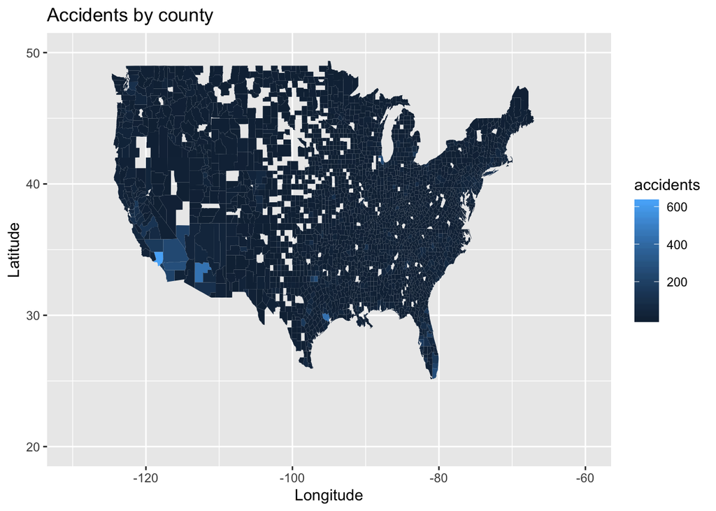

```r
US_GLC<- readxl::read_xlsx('FRPP_GLC_UnitedStatesFeb132020.xlsx')
county<- map_data('county')
county <- county %>%
  mutate(`State Name` = region, `County Name` = subregion) %>%
  select(`State Name`, `County Name`, long, lat, group, order)

US_GLC$STATE <- as.integer(US_GLC$`State Code`)
US_GLC$COUNTY <- as.integer(US_GLC$`County Code`)
US_GLC$`State Name` <- tolower(US_GLC$`State Name`)
US_GLC$`County Name` <- tolower(US_GLC$`County Name`)


county_acc = acc %>%
  group_by(STATE,COUNTY) %>%
  summarise(accidents = n())

joined_dat = US_GLC %>%
  inner_join(county_acc,by=c('STATE','COUNTY'))


county %>%
  inner_join(joined_dat, by = c("State Name", "County Name")) %>%
  ggplot(mapping=aes(x=long, y=lat)) + geom_polygon(aes(group=group, fill=accidents)) +
  xlim(c(-130, -60)) + ylim(c(20,50)) + xlab('Longitude') + ylab('Latitude') +
  ggtitle('Accidents by county')
```

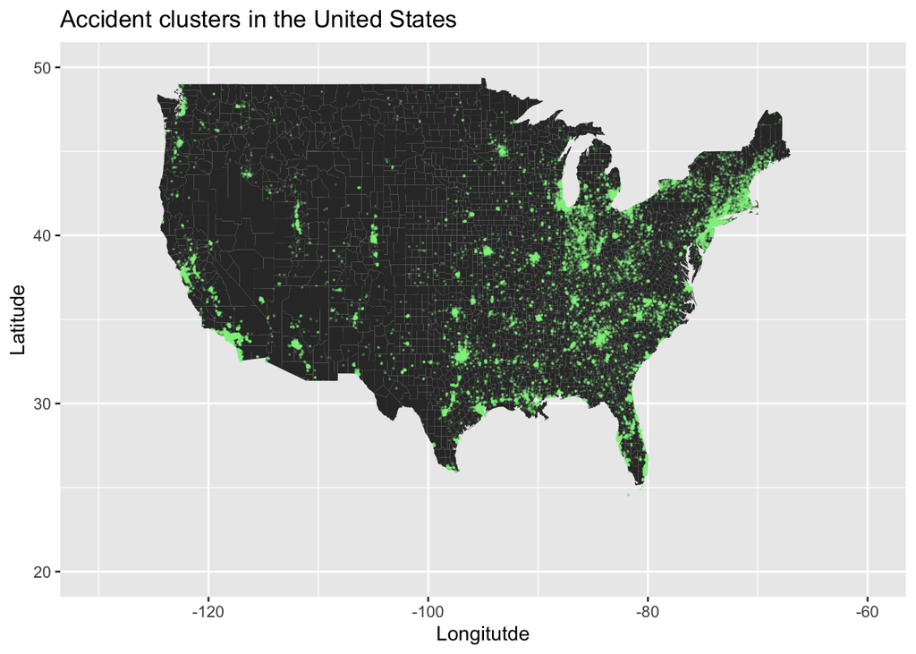

```r
US_GLC<- readxl::read_xlsx('FRPP_GLC_UnitedStatesFeb132020.xlsx')
county<- map_data('county')


#2
US_GLC2 <- US_GLC %>%
  mutate(`State Code` = as.integer(`State Code`), `County Code` = as.integer(`County Code`), `City Code` = as.integer(`City Code`)) %>%
  inner_join(combined, c(`County Code` = 'COUNTY', `State Code` = 'STATE', `City Code` = 'CITY'))

ggplot(county, mapping=aes(x=long, y=lat)) + geom_polygon(mapping = aes(group=group, fill=)) + geom_point(US_GLC2, mapping = aes(x=LONGITUD, y=LATITUDE), color='lightgreen', alpha=.2, size=.02) + xlim(c(-130, -60)) + ylim(c(20,50)) + xlab('Longitutde') + ylab('Latitude') + ggtitle('Accident clusters in the United States')
```

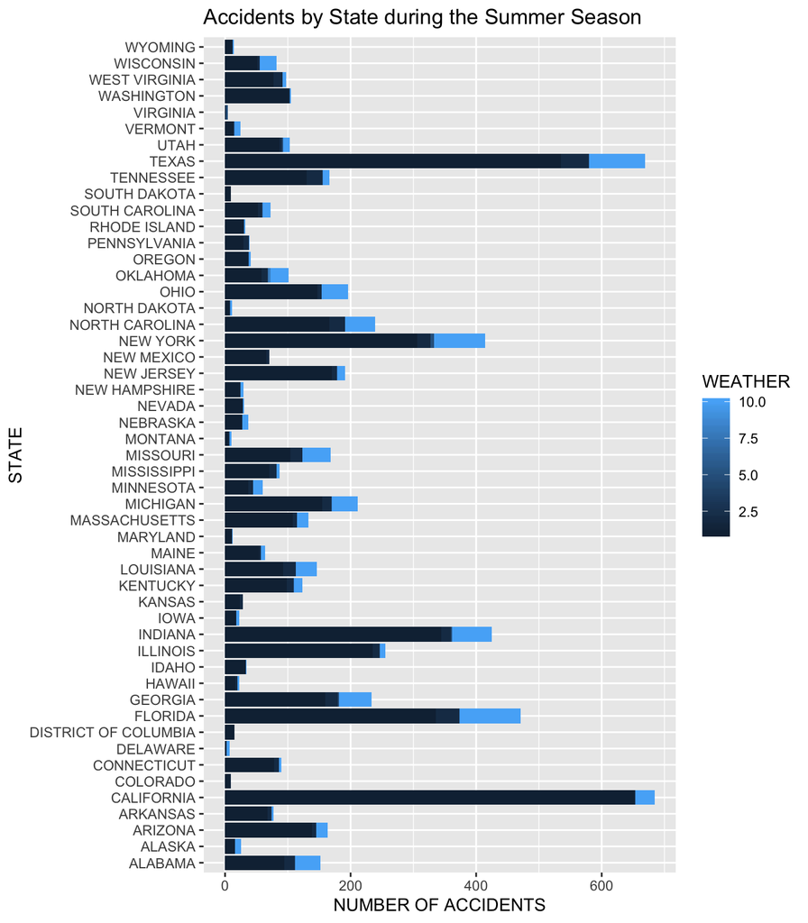

```r
US_GLC2 %>%
  filter(MONTH == 6 | MONTH == 7 | MONTH == 8) %>%
  filter(WEATHER < 98) %>%
  group_by(`State Name`, WEATHER, MONTH) %>%
  summarise(n = n()) %>%
  ggplot(acc, mapping = aes(x=`State Name`, y=n, fill=WEATHER)) + geom_col() + coord_flip() + xlab('STATE') + ylab('NUMBER OF ACCIDENTS') + ggtitle("Accidents by State during the Summer Season")
```

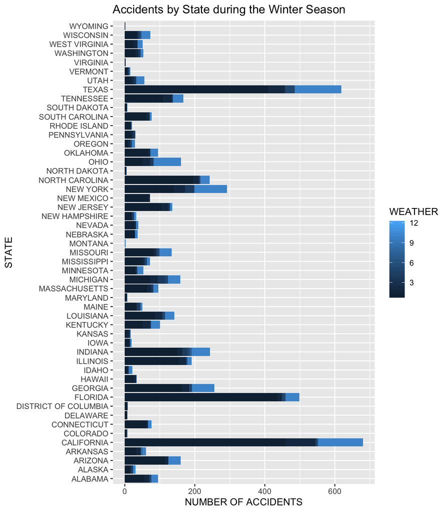

```r
US_GLC2 %>%
  filter(MONTH == 12 | MONTH == 1 | MONTH == 2) %>%
  filter(WEATHER < 98) %>%
  group_by(`State Name`, WEATHER, MONTH) %>%
  summarise(n = n()) %>%
  ggplot(acc, mapping = aes(x=`State Name`, y=n, fill=WEATHER)) + geom_col() + coord_flip() + xlab('STATE') + ylab('NUMBER OF ACCIDENTS') + ggtitle("Accidents by State during the Winter Season")
```

Comparing the above two graphs, we see that in non-southern states, more accidents occur during the summer months than during the winter months. However, in the warmer, more southern states there is no seasonal trend. This can be understood by considering that there is not much difference in weather year-round for the southern states.